# session_7_bivariate_analysis

- Basic dataframe operations
- Categorical column analysis
  - frequency table
  - Relative frequency table
  - bar chart
  - pie chart
  - subplots
- Numerical column analysis
  - Statistical operations
  - Percentile Quantile
  - Emperical rule
  - histogram
  - boxplot
- Outlier analysis
  - Box plot analysis
  - How to find the outliers
  - How to treat the outliers

# Bi-multi variate analysis

```python
import pandas as pd
import numpy as np
import matplotlib.pyplot as plt
import seaborn as sns
```

```python
visa_df=pd.read_csv('Visadataset.csv')
visa_df
```

|  | case_id | continent | education_of_employee | has_job_experience | requires_job_training | no_of_employees | yr_of_estab | region_of_employment | prevailing_wage | unit_of_wage | full_time_position | case_status |
| --- | --- | --- | --- | --- | --- | --- | --- | --- | --- | --- | --- | --- |
| 0 | EZYV01 | Asia | High School | N | N | 14513 | 2007 | West | 592.2029 | Hour | Y | Denied |
| 1 | EZYV02 | Asia | Master's | Y | N | 2412 | 2002 | Northeast | 83425.6500 | Year | Y | Certified |
| 2 | EZYV03 | Asia | Bachelor's | N | Y | 44444 | 2008 | West | 122996.8600 | Year | Y | Denied |
| 3 | EZYV04 | Asia | Bachelor's | N | N | 98 | 1897 | West | 83434.0300 | Year | Y | Denied |
| 4 | EZYV05 | Africa | Master's | Y | N | 1082 | 2005 | South | 149907.3900 | Year | Y | Certified |
| ... | ... | ... | ... | ... | ... | ... | ... | ... | ... | ... | ... | ... |
| 25475 | EZYV25476 | Asia | Bachelor's | Y | Y | 2601 | 2008 | South | 77092.5700 | Year | Y | Certified |
| 25476 | EZYV25477 | Asia | High School | Y | N | 3274 | 2006 | Northeast | 279174.7900 | Year | Y | Certified |
| 25477 | EZYV25478 | Asia | Master's | Y | N | 1121 | 1910 | South | 146298.8500 | Year | N | Certified |
| 25478 | EZYV25479 | Asia | Master's | Y | Y | 1918 | 1887 | West | 86154.7700 | Year | Y | Certified |
| 25479 | EZYV25480 | Asia | Bachelor's | Y | N | 3195 | 1960 | Midwest | 70876.9100 | Year | Y | Certified |

25480 rows × 12 columns

```python
cat_cols=visa_df.select_dtypes(include='object').columns
num_cols=visa_df.select_dtypes(exclude='object').columns
num_cols, cat_cols
```

```
(Index(['no_of_employees', 'yr_of_estab', 'prevailing_wage'], dtype='object'),
 Index(['case_id', 'continent', 'education_of_employee', 'has_job_experience',
        'requires_job_training', 'region_of_employment', 'unit_of_wage',
        'full_time_position', 'case_status'],
       dtype='object'))
```

**task**

- lets take continent and case_status
- continent has 6 labels are there, each label has different count
- case status has 2 labels certified and denied
- i want to know how many asia applicants visa certified and how many denied

```python
visa_df['continent'].value_counts()
```

```
continent
Asia             16861
Europe            3732
North America     3292
South America      852
Africa             551
Oceania            192
Name: count, dtype: int64
```

```python
visa_df['case_status'].value_counts()
```

```
case_status
Certified    17018
Denied        8462
Name: count, dtype: int64
```

```python
# step-1: con1=visa_df['continent']=='asia'
# step-2: con2= visa['cs']=='cert'
# step-3: cert_con=con1&con2
# step-4: visa_df[cert_con]
```

```python
con1=visa_df['continent']=='Asia'
con2=visa_df['case_status']=='Certified'

cert_con=con1&con2

len(visa_df[cert_con])
```

```
11012
```

```python
con1=visa_df['continent']=='Asia'
con2=visa_df['case_status']=='Certified'
con3=visa_df['case_status']=='Denied'

certi_con=con1&con2

den_con=con1&con3

print(len(visa_df[certi_con]))
print(len(visa_df[den_con]))
```

```
11012
5849
```

```python
con1=visa_df['continent']=='Asia'
con2=visa_df['case_status']=='Denied'

con=con1&con2

len(visa_df[con])
```

```
5849
```

```python
visa_df['case_status']
```

```
0           Denied
1        Certified
2           Denied
3           Denied
4        Certified
           ...
25475    Certified
25476    Certified
25477    Certified
25478    Certified
25479    Certified
Name: case_status, Length: 25480, dtype: object
```

```python
con1=visa_df['continent']=='Asia'
con2=visa_df['case_status']=='Certified'
con3=visa_df['case_status']=='Denied'
cert_con=con1&con2
den_con=con1&con3
cert_data=visa_df[cert_con]
den_data=visa_df[den_con]
print("certified applicants from Asia is:",len(cert_data))
print("denied applicants from Asia is:",len(den_data))
```

```
certified applicants from Asia is: 11012
denied applicants from Asia is: 5849
```

```python
for i in visa_df['continent'].unique():
    con1=visa_df['continent']==i
    con2=visa_df['case_status']=='Certified'
    con3=visa_df['case_status']=='Denied'
    cert_con=con1&con2
    den_con=con1&con3
    cert_data=visa_df[cert_con]
    den_data=visa_df[den_con]
    print(f"certified applicants from {i} is:",len(cert_data))
    print(f"denied applicants from {i} is:",len(den_data))
```

```
certified applicants from Asia is: 11012
denied applicants from Asia is: 5849
certified applicants from Africa is: 397
denied applicants from Africa is: 154
certified applicants from North America is: 2037
denied applicants from North America is: 1255
certified applicants from Europe is: 2957
denied applicants from Europe is: 775
certified applicants from South America is: 493
denied applicants from South America is: 359
certified applicants from Oceania is: 122
denied applicants from Oceania is: 70
```

```python
visa_df['continent'].unique()
```

```
array(['Asia', 'Africa', 'North America', 'Europe', 'South America',
       'Oceania'], dtype=object)
```

```python
labels=visa_df['continent'].unique()

cert_len=[]
den_len=[]
for i in labels:
    con1=visa_df['continent']==i
    con2=visa_df['case_status']=='Certified'
    con3=visa_df['case_status']=='Denied'
    cert_con=con1&con2
    den_con=con1&con3

    cert_len.append(len(visa_df[cert_con]))
    den_len.append(len(visa_df[den_con]))

pd.DataFrame(zip(den_len,cert_len),index=labels,
             columns=visa_df['case_status'].unique())
```

|  | Denied | Certified |
| --- | --- | --- |
| Asia | 5849 | 11012 |
| Africa | 154 | 397 |
| North America | 1255 | 2037 |
| Europe | 775 | 2957 |
| South America | 359 | 493 |
| Oceania | 70 | 122 |

```python
for i in cat_cols[1:]:
    print(i)
```

```
continent
education_of_employee
has_job_experience
requires_job_training
region_of_employment
unit_of_wage
full_time_position
case_status
```

**cross tab**

```python
col1=visa_df['continent']
col2=visa_df['case_status']
pd.crosstab(col1,col2)
```

| case_status continent | Certified | Denied |
| --- | --- | --- |
| Africa | 397 | 154 |
| Asia | 11012 | 5849 |
| Europe | 2957 | 775 |
| North America | 2037 | 1255 |
| Oceania | 122 | 70 |
| South America | 493 | 359 |

```python
col1=visa_df['continent']
col2=visa_df['case_status']
pd.crosstab(col2,col1)
```

| continent case_status | Africa | Asia | Europe | North America | Oceania | South America |
| --- | --- | --- | --- | --- | --- | --- |
| Certified | 397 | 11012 | 2957 | 2037 | 122 | 493 |
| Denied | 154 | 5849 | 775 | 1255 | 70 | 359 |

```python
col1=visa_df['continent']
col2=visa_df['case_status']
col3=visa_df['education_of_employee']

id=col1
cols=[col3,col2]
pd.crosstab(index=col1,columns=cols)
```

| education_of_employee case_status continent | Bachelor's Certified | Bachelor's Denied | Doctorate Certified | Doctorate Denied | High School Certified | High School Denied | Master's Certified | Master's Denied |
| --- | --- | --- | --- | --- | --- | --- | --- | --- |
| Africa | 81 | 62 | 43 | 11 | 23 | 43 | 250 | 38 |
| Asia | 4407 | 2761 | 780 | 143 | 676 | 1614 | 5149 | 1331 |
| Europe | 1040 | 259 | 788 | 58 | 162 | 328 | 967 | 130 |
| North America | 641 | 584 | 207 | 51 | 210 | 191 | 979 | 429 |
| Oceania | 38 | 28 | 19 | 3 | 19 | 17 | 46 | 22 |
| South America | 160 | 173 | 75 | 14 | 74 | 63 | 184 | 109 |

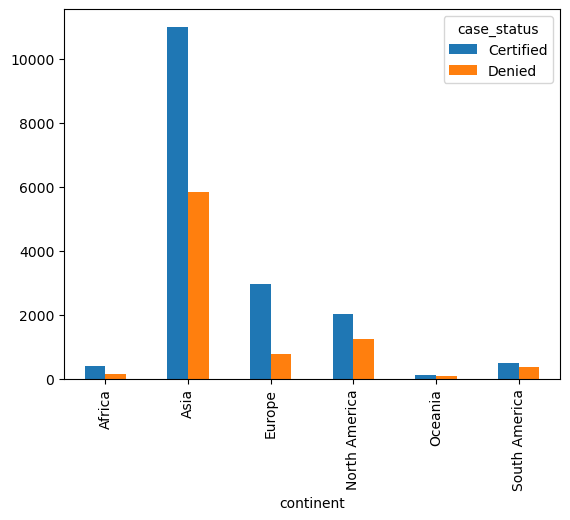

```python
col1=visa_df['continent']
col2=visa_df['case_status']
r1=pd.crosstab(col1,col2)
r1.plot(kind='bar')
# how to add number on bar
```

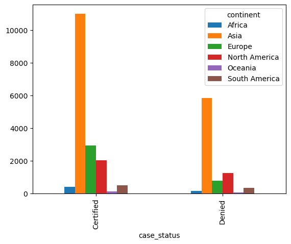

```python
col1=visa_df['continent']
col2=visa_df['case_status']
r2=pd.crosstab(col2,col1)
r2.plot(kind='bar')
```

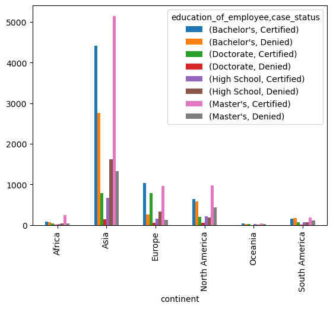

```python
col1=visa_df['continent']
col2=visa_df['case_status']
col3=visa_df['education_of_employee']

id=col1
cols=[col3,col2]

r3=pd.crosstab(index=col1,columns=cols)
r3.plot(kind='bar')
```

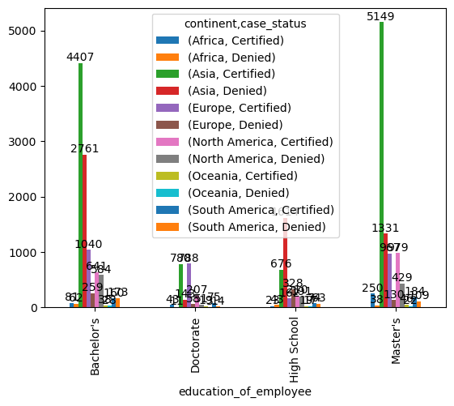

```python
col1=visa_df['continent']
col2=visa_df['case_status']
col3=visa_df['education_of_employee']

id=col3
cols=[col1,col2]
plt.figure(figsize=(30,15))
r3=pd.crosstab(index=col3,columns=cols,)
visulize=r3.plot(kind='bar')
for i in visulize.containers:
    visulize.bar_label(i,fmt="%d")
plt.show()
```

**scatter plot**

- scatter plots used for identify the relation between two numerical columns
- it is under matplotlib **plt.scatter**

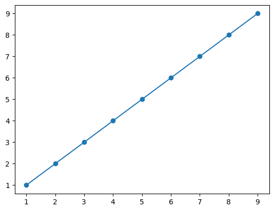

```python
x=range(1,10) # [i for i in range(1,10)]
y=range(1,10)  # [i for i in range(1,10)]
plt.scatter(x,y)  # dots
plt.plot(x,y)   # dots connected
```

```python
x   y
-4  16
-3  9
-2  4
-1  1
0   0
1   1
2   4
3   9
4   16
```

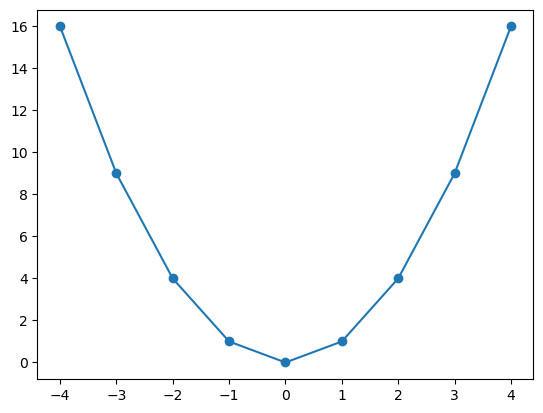

```python
x=range(-4,5)
y=[i**2 for i in x]

plt.scatter(x,y)
plt.plot(x,y)
```

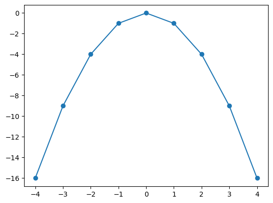

```python
x=range(-4,5)
y=[-i**2 for i in x]

plt.scatter(x,y)
plt.plot(x,y)
plt.show()
```

```python
for i in visulize.containers:
    visulize.bar_label(i,fmt="%d")
plt.show()
```

```python
num_cols
```

```
Index(['no_of_employees', 'yr_of_estab', 'prevailing_wage'], dtype='object')
```

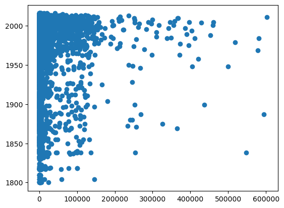

```python
col1=visa_df['no_of_employees']
col2=visa_df['yr_of_estab']
plt.scatter(col1,col2)
```

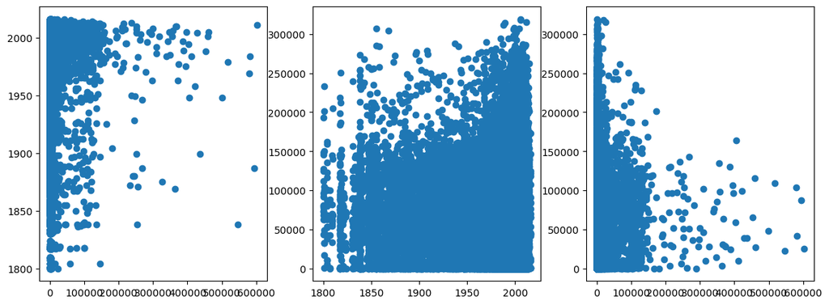

```python
col1=visa_df['no_of_employees']
col2=visa_df['yr_of_estab']
col3=visa_df['prevailing_wage']

plt.figure(figsize=(14,5))

plt.subplot(1,3,1).scatter(col1,col2)
plt.subplot(1,3,2).scatter(col2,col3)
plt.subplot(1,3,3).scatter(col1,col3)
```

- by seeing the graph we are not able to explain the relationship properly
- for this we need to get correlation matrix
- it is provides the values between -1 to 1
  - -1 to 0 indicates negative relation
  - close to 0 or exactly 0 indicates no reltion
  - 1 to 0 indicate postive reltion
- the method name is data.corr

[figure not shown]

```python
visa_df.corr(numeric_only=True)
```

|  | no_of_employees | yr_of_estab | prevailing_wage |
| --- | --- | --- | --- |
| no_of_employees | 1.000000 | -0.017770 | -0.009523 |
| yr_of_estab | -0.017770 | 1.000000 | 0.012342 |
| prevailing_wage | -0.009523 | 0.012342 | 1.000000 |

- we have total 3 numerical columns
- so we are getting a 3x3 matrix
- other than diagnoal values all other are close to zero
- which indicates the columns does not have any reltion

**heat map**

- assume that we have 10 columns are there
- then the matrix has 10x10 total 100 values
- it is hard find quickly the highest value and lowest value
- for that **heat map visualization is always bettere**
- heat map will provide colors to range of values
  - Example -1 to -0.5 indicate as black color
  - by seeing the black color the user can immediately think about the value range
- it is available in this seaborn : **sns.heatmap**

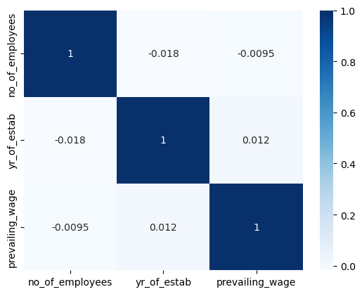

```python
corr=visa_df.corr(numeric_only=True)
sns.heatmap(corr,
            annot=True,
            cmap='Blues')
```